# US-dairy analysis

## Inspired by David Robinson

We would like to analyze US-dairy data, particularly on consumption of dairy products as well as cheese products. Details of this series can be found here [us-dairy](https://github.com/rfordatascience/tidytuesday/tree/master/data/2019/2019-01-29). There are some other datasets for this series of tidytuesday, but we will only look at two datasets.

# Get data from tidytuesday repo

```r
library(tidyverse)
theme_set(theme_light())
milk_products_facts <- read_csv("https://raw.githubusercontent.com/rfordatascience/tidytuesday/master/data/2019/2019-01-29/milk_products_facts.csv")
cheese <- read_csv("https://raw.githubusercontent.com/rfordatascience/tidytuesday/master/data/2019/2019-01-29/clean_cheese.csv")
```

# Milk Product Data

We first are going to look at the milk product facts. The data has a typical format that needs to be gathered. We also need to separate product into product and category for more focused analysis.

```r
milk_products_tidied <- milk_products_facts %>%
  gather(product, lbs_per_person, -year) %>%
  separate(product, c("category", "product", sep = "_",
                      extra = "merge", fill = "right")) %>%
  mutate(product = coalesce(product, category),
         product = str_to_title(str_replace_all(product, "_", " ")),
         category = str_to_title(category),
         product = ifelse(product == "Other", paste(product, category), product))
```

## Daily consumption by category

Now, we will plot daily consumption of dairy products by category.

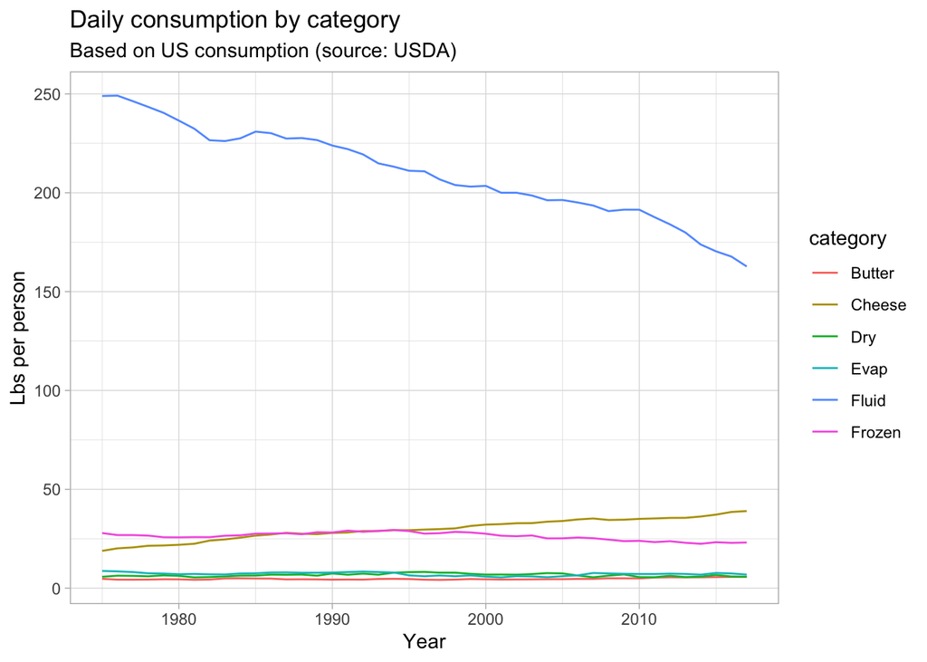

```r
milk_products_tidied %>%
  group_by(category, year) %>%
  summarise(lbs_per_person = sum(lbs_per_person)) %>%
  ggplot(aes(year, lbs_per_person, color = category)) +
  geom_line() +
  labs(title = "Daily consumption by category",
       subtitle = "Based on US consumption (source: USDA)",
       x = "Year",
       y = "Lbs per person")
```

There is nothing striking here and it’s very hard to compare different categories as they have similar trends, except for ‘Fluid’, which can be considered as an outlier.

## Daily consumption by product

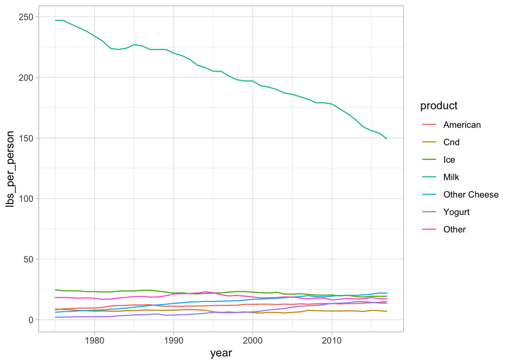

```r
milk_products_tidied %>%
  group_by(product = fct_lump(product, 6, w = lbs_per_person),
           year) %>%
  summarise(lbs_per_person = sum(lbs_per_person)) %>%
  ggplot(aes(year, lbs_per_person, color = product)) +
  geom_line()
```

Similar to previous analysis on different categories, it’s hard to observe any meaningful trend. So, we will consider using facet_wrap to zoom in more closely.

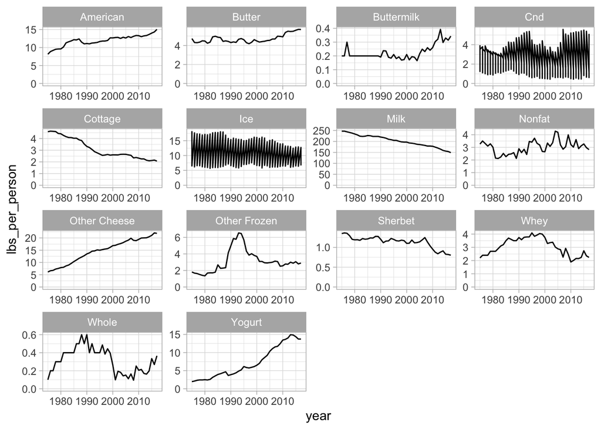

```r
milk_products_tidied %>%
  ggplot(aes(year, lbs_per_person)) +
  geom_line() +
  facet_wrap(~ product, scales="free") +
  expand_limits(y = 0)
```

We now are able to see more observable trend for different products. Yet, the data may not be useful for time-series forecasting as we don’t observe any seasonal trend on any products.

We will observe how different categorys and products change for different decades. It’s expected that we won’t see any observable trend since ‘Milk’ dominates the analysis. So, we can choose not to display ‘Milk’.

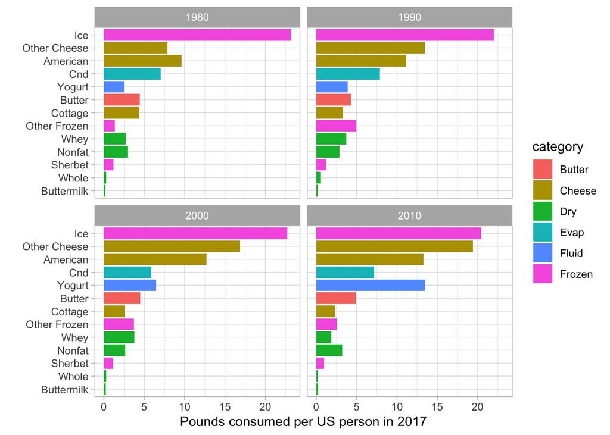

```r
milk_products_tidied %>%
  filter(year %in% c(1980, 1990, 2000, 2010),
         product != "Milk") %>%
  mutate(product = fct_reorder(product, lbs_per_person, sum)) %>%
  ggplot(aes(product, lbs_per_person, fill = category)) +
  facet_wrap(~ year) +
  geom_col() +
  coord_flip() +
  labs(x = "",
       y = "Pounds consumed per US person in 2017")
```

Interestingly, we can see more consumption of ‘Other Cheese’, ‘American’ and ‘Yogurt’.

## Forecasting

We did mention earlier that the data may not be good for forecasting due to the lack of seasonal trend. Nonetheless, this can be a good practice to use some libraries for time-series forecasting such as timetk and sweep.

```r
library(sweep)
library(timetk)
library(lubridate)
library(forecast)

milk_product_ts <- milk_products_tidied %>%
  mutate(year = as.Date("0001-01-01") + years(year - 1)) %>%
  nest(-category, -product) %>%
  mutate(ts = map(data, tk_ts, start = 1975, freq = 1))

milk_product_ets <- milk_product_ts %>%
  mutate(model = map(ts, ets))

milk_product_ets %>%
  mutate(glanced = map(model, sw_glance)) %>%
  unnest(glanced)
```

```
## # A tibble: 14 x 17
##    category product data  ts    model model.desc  sigma  logLik    AIC    BIC
##    <chr>    <chr>   <lis> <lis> <lis> <chr>       <dbl>   <dbl>  <dbl>  <dbl>
##  1 Fluid    Milk    <tib… <ts>  <ets> ETS(A,A,N) 2.05   -110.    229.   238.
##  2 Fluid    Yogurt  <tib… <ts>  <ets> ETS(M,A,N) 0.0694  -40.3    90.7   99.5
##  3 Butter   Butter  <tib… <ts>  <ets> ETS(A,N,N) 0.192    -8.92   23.8   29.1
##  4 Cheese   Americ… <tib… <ts>  <ets> ETS(A,Ad,… 0.352   -33.3    78.7   89.3
##  5 Cheese   Other … <tib… <ts>  <ets> ETS(M,A,N) 0.0214  -26.4    62.7   71.5
##  6 Cheese   Cottage <tib… <ts>  <ets> ETS(A,Ad,… 0.0799   30.5   -48.9  -38.4
##  7 Evap     Cnd     <tib… <ts>  <ets> ETS(A,N,N) 1.60   -373.    752.   761.
##  8 Frozen   Ice     <tib… <ts>  <ets> ETS(M,A,N) 0.426  -323.    656.   668.
##  9 Frozen   Sherbet <tib… <ts>  <ets> ETS(A,N,N) 0.0510   48.1   -90.2  -84.9
## 10 Frozen   Other … <tib… <ts>  <ets> ETS(M,N,N) 0.172   -49.0   104.   109.
## 11 Dry      Whole   <tib… <ts>  <ets> ETS(A,N,N) 0.0782   29.8   -53.5  -48.2
## 12 Dry      Nonfat  <tib… <ts>  <ets> ETS(M,N,N) 0.148   -44.9    95.7  101.
## 13 Dry      Butter… <tib… <ts>  <ets> ETS(M,N,N) 0.141    69.7  -133.  -128.
## 14 Dry      Whey    <tib… <ts>  <ets> ETS(A,N,N) 0.260   -22.0    50.0   55.3
## # … with 7 more variables: ME <dbl>, RMSE <dbl>, MAE <dbl>, MPE <dbl>,
## #   MAPE <dbl>, MASE <dbl>, ACF1 <dbl>
```

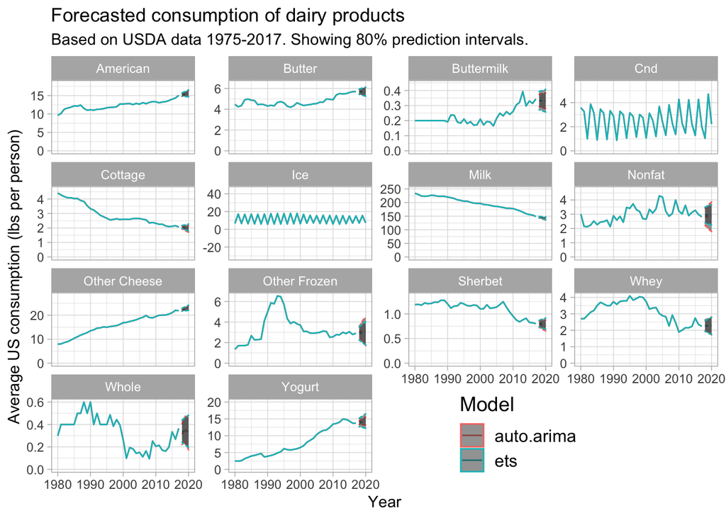

```r
milk_product_ts %>%
  crossing(model_name = c("auto.arima", "ets")) %>%
  mutate(model = map2(model_name, ts, ~ invoke(.x, list(.y))),
         forecast = map(model, forecast, h = 10)) %>%
  mutate(sweep = map(forecast, sw_sweep)) %>%
  unnest(sweep) %>%
  ggplot(aes(index, lbs_per_person, color = model_name, lty = key)) +
  geom_line() +
  geom_ribbon(aes(ymin = lo.80, ymax = hi.80), alpha = .5) +
  facet_wrap(~ product, scales = "free_y") +
  expand_limits(y = 0) +
  xlim(c(1980, 2020)) +
  scale_linetype_discrete(guide = FALSE) +
  labs(x = "Year",
       y = "Average US consumption (lbs per person)",
       title = "Forecasted consumption of dairy products",
       subtitle = "Based on USDA data 1975-2017. Showing 80% prediction intervals.",
       color = "Model") +
  theme(legend.position = c(0.7, 0.1),
        legend.text = element_text(size = 12),
        legend.title = element_text(size = 14))
```

# Looking at Cheese data

We will perform similar analysis that we did earlier for milk products to cheese data.

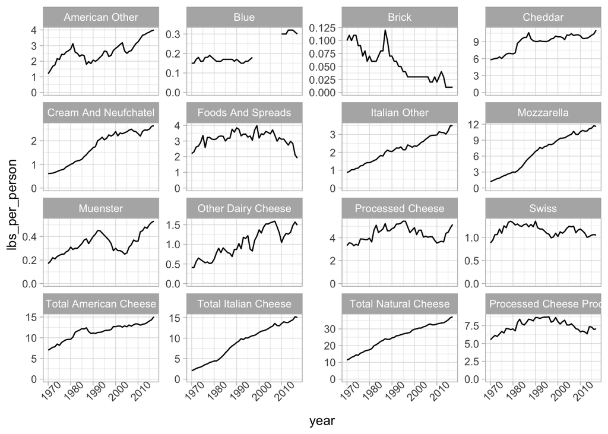

```r
cheese_tidied <- cheese %>%
  gather(type, lbs_per_person, -Year) %>%
  rename(year = Year) %>%
  mutate(type = str_to_title(type),
         type = fct_recode(type, "Total American Cheese" = "Total American Chese"))

cheese_tidied %>%
  ggplot(aes(year, lbs_per_person)) +
  geom_line() +
  facet_wrap(~ type, scales = "free_y") +
  expand_limits(y = 0) +
  theme(axis.text.x = element_text(angle = 45))
```

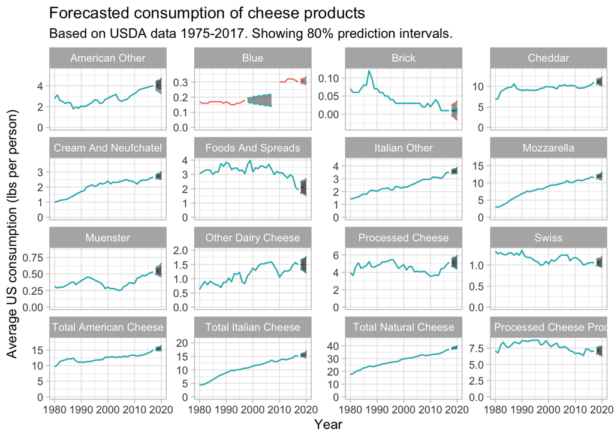

```r
cheese_ts <- cheese_tidied %>%
  mutate(year = as.Date("0001-01-01") + years(year - 1)) %>%
  nest(-type) %>%
  mutate(ts = map(data, tk_ts, start = 1970, freq = 1))

cheese_ts %>%
  crossing(model_name = c("auto.arima", "ets")) %>%
  mutate(model = map2(model_name, ts, ~ invoke(.x, list(.y))),
         forecast = map(model, forecast::forecast, h = 10)) %>%
  mutate(sweep = map(forecast, sw_sweep)) %>%
  unnest(sweep) %>%
  ggplot(aes(index, lbs_per_person, color = model_name, lty = key)) +
  geom_line() +
  geom_ribbon(aes(ymin = lo.80, ymax = hi.80), alpha = .5) +
  facet_wrap(~ type, scales = "free_y") +
  expand_limits(y = 0) +
  xlim(c(1980, 2020)) +
  scale_linetype_discrete(guide = FALSE) +
  labs(x = "Year",
       y = "Average US consumption (lbs per person)",
       title = "Forecasted consumption of cheese products",
       subtitle = "Based on USDA data 1975-2017. Showing 80% prediction intervals.",
       color = "Model") +
  guides(color = FALSE)
```

- Due to the missing data for ‘Blue’ cheese, the forecasting result for it isn’t really useful at all. We may need to do something and look deeper into the data as there are quite a lot of missing values.

## Possible improvement:

- Create shiny app for people to explore different cheese
- Create function to make codes more efficient